# M504Assessment_GH1025910

#### Define Business Problem

**My Client Company is a Local Perfume Brand operating in Indonesia, they possess a Dataset with the attributes deatiling about the various aspects of their perfumes such as brand,Instagram followers, year of release, fragnance varients,concentration,size,price,price per millimeter,& detailed notes on the top,mid and base fragnance components,As a Junior Data Scientist my role here is to assisting clients on setting competetive prices based on market positioning of their perfumes,target audience preferences and industry trends. Overall the Goal of EDA here is to help my clients in optimize their pricing startergy,enhance profitability and make informed decisions regarding product pricing in a competitive perfume market.

#### Data Collection####

Data link :: https://www.kaggle.com/datasets/gantisumpah/indonesian-local-perfume-brand/data

```python
## Importing Basic Libraries requied for this EDA project ##
import pandas as pa
import numpy as nm
import matplotlib.pyplot as pt
import seaborn as sb
from pandasql import sqldf
%matplotlib inline
```

```python
perfume= pa.read_csv('Indonesian Local Perfume Brands.csv')
```

#### Data Understanding

- Data Shape.
- Head(top 5 rows) and tail(Bottom 5 rows).
- dtypes.
- describe.
- Null Values.
- Duplicated values.

```python
##creating the copy of Original DataFrame:-
df=perfume.copy()
##will retain "perfume" as Original Dataframe and use "df" for further steps/analysis
```

```python
# Data shape #
perfume.shape
```

```
(120, 35)
```

```python
perfume.head()
```

|  | brand | instagram_link | followers | year | variant | variant_link | concentration | size | price | price_per_ml | ... | base_notes1 | base_notes2 | base_notes3 | base_notes4 | base_notes5 | base_notes6 | Unnamed: 31 | Unnamed: 32 | Unnamed: 33 | base_notes7 |
| --- | --- | --- | --- | --- | --- | --- | --- | --- | --- | --- | --- | --- | --- | --- | --- | --- | --- | --- | --- | --- | --- |
| 0 | Alchemist | https://www.instagram.com/alchemist.fragrance/ | 17800 | 2022 | Powder Room | https://shopee.co.id/alchemist.fragrance/17137... | EDP | 50 | 199,000.00 | 3,980.00 | ... | Musk | Marine | Sandalwood | NaN | NaN | NaN | NaN | NaN | NaN | NaN |
| 1 | Alien Objects | https://www.instagram.com/alienobjects/ | 15700 | 2019 | XOXO | https://shopee.co.id/alienobjects/14283008217 | EDP | 50 | 750,000.00 | 15,000.00 | ... | NaN | NaN | NaN | NaN | NaN | NaN | NaN | NaN | NaN | NaN |
| 2 | ALT Perfumery | https://www.instagram.com/alt.perfumery/ | 6528 | 2021 | Moroccan Sunset | https://shopee.co.id/altperfumery/12639590547 | EDP | 50 | 229,000.00 | 4,580.00 | ... | Vanilla | Caramel | Musk | Cedarwood | NaN | NaN | NaN | NaN | NaN | NaN |
| 3 | Ara Scent | https://www.instagram.com/ara.scent/ | 119 | 2023 | Sogno | https://shopee.co.id/ara.scent/22247002537 | EDP | 30 | 139,000.00 | 4,633.33 | ... | Amber | Vanilla | NaN | NaN | NaN | NaN | NaN | NaN | NaN | NaN |
| 4 | Aromes | https://www.instagram.com/aromes.id/ | 15700 | 2022 | Crazy Sexy | https://shopee.co.id/aromes.id/19521086160 | EDP | 50 | 299,000.00 | 5,980.00 | ... | Vanilla | Patchouli | Cashmeran | Musk | NaN | NaN | NaN | NaN | NaN | NaN |

5 rows × 35 columns

```python
perfume.tail()
```

|  | brand | instagram_link | followers | year | variant | variant_link | concentration | size | price | price_per_ml | ... | base_notes1 | base_notes2 | base_notes3 | base_notes4 | base_notes5 | base_notes6 | Unnamed: 31 | Unnamed: 32 | Unnamed: 33 | base_notes7 |
| --- | --- | --- | --- | --- | --- | --- | --- | --- | --- | --- | --- | --- | --- | --- | --- | --- | --- | --- | --- | --- | --- |
| 115 | Verites | https://www.instagram.com/verites.id/ | 745 | 2023 | Joie De Vivre | https://shopee.co.id/verites.id/23716180495 | EDP | 50 | 199,000.00 | 3,980.00 | ... | White Musk | Amber | Patchouli | NaN | NaN | NaN | NaN | NaN | NaN | NaN |
| 116 | VNY Perfumery | https://www.instagram.com/vny.idn/ | 530 | 2022 | Daydream | https://shopee.co.id/vnyperfume/11227437209 | EDP | 55 | 249,000.00 | 4,527.27 | ... | Caramel | Vanilla | Benzoin | Resin | NaN | NaN | NaN | NaN | NaN | NaN |
| 117 | VOIIJ. | https://www.instagram.com/voiij.id/ | 8957 | 2021 | Pina Colada | https://shopee.co.id/voiij.id/3795582150 | EDP | 50 | 158,000.00 | 3,160.00 | ... | NaN | NaN | NaN | NaN | NaN | NaN | NaN | NaN | NaN | NaN |
| 118 | YN Perfumery | https://www.instagram.com/yn.perfumery/ | 1540 | 2022 | Rose in September | https://shopee.co.id/ynperfumery/22405366743 | EDP | 50 | 199,000.00 | 3,980.00 | ... | White Musk | Cedarwood | Pepper | Orris Root | Violet Leaf | NaN | NaN | NaN | NaN | NaN |
| 119 | Zior | https://www.instagram.com/ziorparfums/ | 15700 | 2020 | Dose of Love | https://shopee.co.id/ziorofficial/5438049904 | ExDP | 35 | 145,000.00 | 4,142.86 | ... | Musk | White Wood | Vanilla | NaN | NaN | NaN | NaN | NaN | NaN | NaN |

5 rows × 35 columns

```python
perfume.dtypes
```

```
brand             object
instagram_link    object
followers          int64
year               int64
variant           object
variant_link      object
concentration     object
size               int64
price             object
price_per_ml      object
top_notes1        object
top_notes2        object
top_notes3        object
top_notes4        object
top_notes5        object
top_notes6        object
mid_notes1        object
mid_notes2        object
mid_notes3        object
mid_notes4        object
mid_notes5        object
mid_notes6        object
mid_notes7        object
Unnamed: 23       object
Unnamed: 24       object
base_notes1       object
base_notes2       object
base_notes3       object
base_notes4       object
base_notes5       object
base_notes6       object
Unnamed: 31       object
Unnamed: 32       object
Unnamed: 33       object
base_notes7       object
dtype: object
```

```python
perfume.describe().T
```

|  | count | mean | std | min | 25% | 50% | 75% | max |
| --- | --- | --- | --- | --- | --- | --- | --- | --- |
| followers | 120.0 | 26184.166667 | 70833.682520 | 9.0 | 1042.75 | 3430.5 | 15700.0 | 541000.0 |
| year | 120.0 | 2021.291667 | 1.697234 | 2013.0 | 2020.00 | 2022.0 | 2023.0 | 2024.0 |
| size | 120.0 | 51.608333 | 21.069830 | 10.0 | 35.00 | 50.0 | 50.0 | 105.0 |

```python
## Missing values ar null values in Dataset
perfume.isna().sum()
```

```
brand               0
instagram_link      0
followers           0
year                0
variant             0
variant_link        0
concentration       0
size                0
price               0
price_per_ml        0
top_notes1          0
top_notes2          9
top_notes3         41
top_notes4         90
top_notes5        107
top_notes6        113
mid_notes1         10
mid_notes2         20
mid_notes3         50
mid_notes4         94
mid_notes5        109
mid_notes6        116
mid_notes7        117
Unnamed: 23       119
Unnamed: 24       119
base_notes1        16
base_notes2        23
base_notes3        50
base_notes4        87
base_notes5       106
base_notes6       111
Unnamed: 31       119
Unnamed: 32       119
Unnamed: 33       119
base_notes7       116
dtype: int64
```

```python
## Duplicates in the DataSet
perfume.loc[df.duplicated()]
```

|  | brand | instagram_link | followers | year | variant | variant_link | concentration | size | price | price_per_ml | ... | base_notes1 | base_notes2 | base_notes3 | base_notes4 | base_notes5 | base_notes6 | Unnamed: 31 | Unnamed: 32 | Unnamed: 33 | base_notes7 |
| --- | --- | --- | --- | --- | --- | --- | --- | --- | --- | --- | --- | --- | --- | --- | --- | --- | --- | --- | --- | --- | --- |

0 rows × 35 columns

```python
##All the columns in our Dataset##
perfume.columns
```

```
Index(['brand', 'instagram_link', 'followers', 'year', 'variant',
       'variant_link', 'concentration', 'size', 'price', 'price_per_ml',
       'top_notes1', 'top_notes2', 'top_notes3', 'top_notes4', 'top_notes5',
       'top_notes6', 'mid_notes1', 'mid_notes2', 'mid_notes3', 'mid_notes4',
       'mid_notes5', 'mid_notes6', 'mid_notes7', 'Unnamed: 23', 'Unnamed: 24',
       'base_notes1', 'base_notes2', 'base_notes3', 'base_notes4',
       'base_notes5', 'base_notes6', 'Unnamed: 31', 'Unnamed: 32',
       'Unnamed: 33', 'base_notes7'],
      dtype='object')
```

*Observations ##### :- 1)There are 120 rows and 35 columns in our Dataset. 2)There are some Unwanted columns present like: {Unnamed: 23,Unnamed:24,Unnamed:31,Unnamed:32,Unnamed:33} which are of no use in our analysis,we are going to drop that in our Data cleaning steps. 3)There are Null Values present in our Dataset which needs to be handled in our next step. 4)The Data type of Columns:{price,price_per_ml} is Object,as these have decimals prefereble Datatype here is float. 5)No Duplicated Rows are observed in our Dataset.

## Data Cleansing and Preprocessing

1. Removing unwanted columns :{Unnamed: 23,Unnamed:24,Unnamed:31,Unnamed:32,Unnamed:33}

```python
perfume.shape
```

```
(120, 35)
```

```python
df.drop(columns=['Unnamed: 23','Unnamed: 24','Unnamed: 31','Unnamed: 32','Unnamed: 33'],axis=1,inplace=True)
```

```python
df.shape
```

```
(120, 30)
```

```python
df.columns
```

```
Index(['brand', 'instagram_link', 'followers', 'year', 'variant',
       'variant_link', 'concentration', 'size', 'price', 'price_per_ml',
       'top_notes1', 'top_notes2', 'top_notes3', 'top_notes4', 'top_notes5',
       'top_notes6', 'mid_notes1', 'mid_notes2', 'mid_notes3', 'mid_notes4',
       'mid_notes5', 'mid_notes6', 'mid_notes7', 'base_notes1', 'base_notes2',
       'base_notes3', 'base_notes4', 'base_notes5', 'base_notes6',
       'base_notes7'],
      dtype='object')
```

2. Handing the Null Values in our Dataset :- we can see below there are various Null values Present in the notes Attributes below, we are replacing NaN values here by a Defaulting values followed by there first part. example:: for top_notes2 : Nan --> Default_top2 top_notes3 : Nan --> Default_top3.

```python
df.info()
```

```
<class 'pandas.core.frame.DataFrame'>
RangeIndex: 120 entries, 0 to 119
Data columns (total 30 columns):
 #   Column          Non-Null Count  Dtype
---  ------          --------------  -----
 0   brand           120 non-null    object
 1   instagram_link  120 non-null    object
 2   followers       120 non-null    int64
 3   year            120 non-null    int64
 4   variant         120 non-null    object
 5   variant_link    120 non-null    object
 6   concentration   120 non-null    object
 7   size            120 non-null    int64
 8   price           120 non-null    object
 9   price_per_ml    120 non-null    object
```

[output cut: 22 more lines]

```python
df['top_notes2'].unique()
```

```
array(['Rose', 'Strawberry', 'Bergamot', 'Lemon Peel', nan, 'Raspberry',
       'May Rose', 'Orange', 'Passion Fruit', 'Fruit', 'Lemon Verbena',
       'Thyme', 'Pineapple', 'Marine', 'Pink Pepper', 'Lavender',
       'Bitter Orange', 'Gourmand', 'Magnolia', 'Cake', 'Sweet',
       'Gardenia', 'Lemon', 'Kumquat Peel', 'Spicy Notes', 'Saffron',
       'Juniper', 'Peach', 'Mandarin', 'Rosewood', 'Vanilla', 'Jasmine',
       'Lychee', 'Pepper', 'Jasmine Sambac', 'Whiskey', 'Coriander',
       'Spice Ginger', 'Grapefruit', 'Ginger Flower', 'Passion Fruity',
       'Woody', 'Almond', 'Ylang Ylang', 'Aloe Vera', 'Rice',
       'Mandarin Orange', 'Citrus', 'Patchouli', 'Mint', 'Lemon Zest',
       'Pink & Pear Pepper', 'Apple', 'Red Apple', 'Lily of the Valley',
       'Cinnamon', 'Galbanum', 'Aquatic', 'Musk', 'Grass', 'Pear',
       'Green Raspberry', 'Peony', 'Blackcurrant', 'Sandalwood',
       'Bulgarian Rose', 'Iris', 'Pineapple Leaf', 'Wild Berries',
       'Grasse Rose', 'Green Notes', 'Blood Grapefruit'], dtype=object)
```

```python
##top_notes replacement Nulls with Default values ::
df['top_notes2'].replace(to_replace=nm.nan,value='Default_top2',inplace=True)
df['top_notes3'].replace(to_replace=nm.nan,value='Default_top3',inplace=True)
df['top_notes4'].replace(to_replace=nm.nan,value='Default_top4',inplace=True)
df['top_notes5'].replace(to_replace=nm.nan,value='Default_top5',inplace=True)
df['top_notes6'].replace(to_replace=nm.nan,value='Default_top6',inplace=True)
##mid_notes replacement Nulls with Default values ::
df['mid_notes1'].replace(to_replace=nm.nan,value='Default_mid1',inplace=True)
df['mid_notes2'].replace(to_replace=nm.nan,value='Default_mid2',inplace=True)
df['mid_notes3'].replace(to_replace=nm.nan,value='Default_mid3',inplace=True)
df['mid_notes4'].replace(to_replace=nm.nan,value='Default_mid4',inplace=True)
df['mid_notes5'].replace(to_replace=nm.nan,value='Default_mid5',inplace=True)
df['mid_notes6'].replace(to_replace=nm.nan,value='Default_mid6',inplace=True)
df['mid_notes7'].replace(to_replace=nm.nan,value='Default_mid7',inplace=True)
##base_notes replacement Nulls with Default values ::
df['base_notes1'].replace(to_replace=nm.nan,value='Default_base1',inplace=True)
df['base_notes2'].replace(to_replace=nm.nan,value='Default_base2',inplace=True)
df['base_notes3'].replace(to_replace=nm.nan,value='Default_base3',inplace=True)
df['base_notes4'].replace(to_replace=nm.nan,value='Default_base4',inplace=True)
df['base_notes5'].replace(to_replace=nm.nan,value='Default_base5',inplace=True)
df['base_notes6'].replace(to_replace=nm.nan,value='Default_base6',inplace=True)
df['base_notes7'].replace(to_replace=nm.nan,value='Default_base7',inplace=True)
```

```python
## In old Dataset we can still see 1980 Null values present ::
perfume.isna().sum().sum()
```

```
1980
```

```python
## Nan removed Dataset
df.isna().sum()
```

```
brand             0
instagram_link    0
followers         0
year              0
variant           0
variant_link      0
concentration     0
size              0
price             0
price_per_ml      0
top_notes1        0
top_notes2        0
top_notes3        0
top_notes4        0
top_notes5        0
top_notes6        0
mid_notes1        0
mid_notes2        0
mid_notes3        0
mid_notes4        0
mid_notes5        0
mid_notes6        0
mid_notes7        0
base_notes1       0
base_notes2       0
base_notes3       0
base_notes4       0
base_notes5       0
base_notes6       0
base_notes7       0
dtype: int64
```

3. The Data type of Columns:{price,price_per_ml} is Object,as these have decimals prefereble Datatype here is float

```python
df['price_per_ml'].unique()
```

```
array(['3,980.00', '15,000.00', '4,580.00', '4,633.33', '5,980.00',
       '6,980.00', '6,127.27', '2,580.00', '3,833.33', '2,292.50',
       '5,000.00', '1,999.99', '2,224.00', '3,380.00', '4,770.00',
       '2,000.00', '7,000.00', '4,000.00', '2,780.00', '1,690.00',
       '9,133.33', '3,700.00', '3,363.64', '2,500.00', '4,300.00',
       '4,386.67', '2,900.00', '3,400.00', '3,402.00', '17,000.00',
       '5,096.67', '3,000.00', '3,600.00', '2,790.00', '1,419.05',
       '4,980.00', '19,500.00', '3,230.00', '4,700.00', '5,400.00',
       '3,300.00', '2,200.00', '2,327.50', '5,960.00', '4,251.43',
       '19,900.00', '3,266.67', '9,500.00', '4,828.57', '1,076.00',
       '1,499.00', '4,166.67', '7,400.00', '9,333.33', '2,380.00',
       '2,786.00', '3,096.67', '17,780.00', '15,980.00', '3,780.00',
       '3,060.00', '2,010.00', '4,285.71', '7,780.00', '5,833.33',
       '8,800.00', '2,490.00', '3,787.88', '2,750.00', '4,542.86',
       '4,780.00', '7,633.33', '8,300.00', '3,920.00', '3,198.00',
       '6,633.33', '1,990.48', '4,966.67', '5,996.67', '2,980.00',
       '7,225.00', '3,940.00', '3,900.00', '3,685.71', '3,190.00',
       '5,890.00', '2,511.00', '3,240.00', '4,527.27', '3,160.00',
       '4,142.86'], dtype=object)
```

Observation :: As we can see a comma here first it needs to be removed and it needs to be converted to numeric here.

```python
df['price'].str.replace(',','')
```

```
0      199000.00
1      750000.00
2      229000.00
3      139000.00
4      299000.00
         ...
115    199000.00
116    249000.00
117    158000.00
118    199000.00
119    145000.00
Name: price, Length: 120, dtype: object
```

```python
pa.to_numeric(df['price'].str.replace(',',''))
```

```
0      199000.0
1      750000.0
2      229000.0
3      139000.0
4      299000.0
         ...
115    199000.0
116    249000.0
117    158000.0
118    199000.0
119    145000.0
Name: price, Length: 120, dtype: float64
```

```python
df['price']=pa.to_numeric(df['price'].str.replace(',',''))
df['price_per_ml']=pa.to_numeric(df['price_per_ml'].str.replace(',',''))
```

```python
df['price_per_ml'].head(2),df['price'].head(2)
```

```
(0     3980.0
 1    15000.0
 Name: price_per_ml, dtype: float64,
 0    199000.0
 1    750000.0
 Name: price, dtype: float64)
```

```python
##### Cleaned DataSet #####
df.info()
```

```
<class 'pandas.core.frame.DataFrame'>
RangeIndex: 120 entries, 0 to 119
Data columns (total 30 columns):
 #   Column          Non-Null Count  Dtype
---  ------          --------------  -----
 0   brand           120 non-null    object
 1   instagram_link  120 non-null    object
 2   followers       120 non-null    int64
 3   year            120 non-null    int64
 4   variant         120 non-null    object
 5   variant_link    120 non-null    object
 6   concentration   120 non-null    object
 7   size            120 non-null    int64
 8   price           120 non-null    float64
 9   price_per_ml    120 non-null    float64
```

[output cut: 22 more lines]

## Data Exploration and Analsysis

```python
df.describe().T
```

|  | count | mean | std | min | 25% | 50% | 75% | max |
| --- | --- | --- | --- | --- | --- | --- | --- | --- |
| followers | 120.0 | 26184.166667 | 70833.682520 | 9.0 | 1042.7500 | 3430.5 | 15700.0 | 541000.0 |
| year | 120.0 | 2021.291667 | 1.697234 | 2013.0 | 2020.0000 | 2022.0 | 2023.0 | 2024.0 |
| size | 120.0 | 51.608333 | 21.069830 | 10.0 | 35.0000 | 50.0 | 50.0 | 105.0 |
| price | 120.0 | 240903.325000 | 175383.014841 | 53800.0 | 148950.0000 | 185000.0 | 249250.0 | 995000.0 |
| price_per_ml | 120.0 | 4989.979417 | 3440.083782 | 1076.0 | 3144.1675 | 3980.0 | 5400.0 | 19900.0 |

```python
sqldf(" select * from df where followers in (9.0,541000.0)")
```

|  | brand | instagram_link | followers | year | variant | variant_link | concentration | size | price | price_per_ml | ... | mid_notes5 | mid_notes6 | mid_notes7 | base_notes1 | base_notes2 | base_notes3 | base_notes4 | base_notes5 | base_notes6 | base_notes7 |
| --- | --- | --- | --- | --- | --- | --- | --- | --- | --- | --- | --- | --- | --- | --- | --- | --- | --- | --- | --- | --- | --- |
| 0 | De.Claires | https://www.instagram.com/de.claires/?hl=en | 541000 | 2018 | Petite Pastry | https://shopee.co.id/de.claires/18404156074 | EDP | 55 | 185000.0 | 3363.64 | ... | Default_mid5 | Default_mid6 | Default_mid7 | Default_base1 | Default_base2 | Default_base3 | Default_base4 | Default_base5 | Default_base6 | Default_base7 |
| 1 | La'vourse | https://www.instagram.com/la.vourse/ | 9 | 2023 | mystère d'Oud | https://shopee.co.id/la.vourse/21877898373 | ExDP | 35 | 148800.0 | 4251.43 | ... | Default_mid5 | Default_mid6 | Default_mid7 | Agarwood | Sandalwood | Incense | Patchouli | Benzoin | Vanilla | Cedarwood |

2 rows × 30 columns

*Observation :: 1)The brand "La'vourse" needs more Social media campagning- The followers are really low(9) and from the price it can be observed that its selling at good market rate and improve in publicity might further improve the selling price of the "La'vourse". 2)The Client Dataset has Data from 2013 to 2024

## Business problem statements :-

**Business Problem statement 1:- Determine if there is a correlation between the price of a product and all other Attributes in the Dataset

```python
df_corr=df.select_dtypes(['float64','int64']).corr()
df_corr
```

|  | followers | year | size | price | price_per_ml |
| --- | --- | --- | --- | --- | --- |
| followers | 1.000000 | -0.334897 | 0.094000 | -0.009985 | -0.035223 |
| year | -0.334897 | 1.000000 | -0.024273 | -0.025851 | -0.047330 |
| size | 0.094000 | -0.024273 | 1.000000 | 0.183330 | -0.231242 |
| price | -0.009985 | -0.025851 | 0.183330 | 1.000000 | 0.889949 |
| price_per_ml | -0.035223 | -0.047330 | -0.231242 | 0.889949 | 1.000000 |

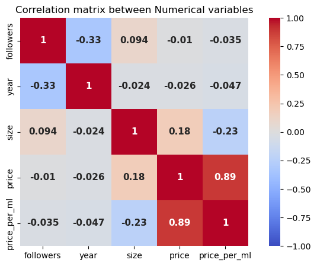

```python
## Heat map for Correlation :-
pt.figure(figsize=(9,5))
sb.heatmap(df_corr,vmin=-1,vmax=1,cmap='coolwarm',square=True,
           annot=True,annot_kws={'fontsize':11,'fontweight':'bold'})
pt.title("Correlation matrix between Numerical variables")
pt.show()
```

```python
df.head(3)
```

|  | brand | instagram_link | followers | year | variant | variant_link | concentration | size | price | price_per_ml | ... | mid_notes5 | mid_notes6 | mid_notes7 | base_notes1 | base_notes2 | base_notes3 | base_notes4 | base_notes5 | base_notes6 | base_notes7 |
| --- | --- | --- | --- | --- | --- | --- | --- | --- | --- | --- | --- | --- | --- | --- | --- | --- | --- | --- | --- | --- | --- |
| 0 | Alchemist | https://www.instagram.com/alchemist.fragrance/ | 17800 | 2022 | Powder Room | https://shopee.co.id/alchemist.fragrance/17137... | EDP | 50 | 199000.0 | 3980.0 | ... | Default_mid5 | Default_mid6 | Default_mid7 | Musk | Marine | Sandalwood | Default_base4 | Default_base5 | Default_base6 | Default_base7 |
| 1 | Alien Objects | https://www.instagram.com/alienobjects/ | 15700 | 2019 | XOXO | https://shopee.co.id/alienobjects/14283008217 | EDP | 50 | 750000.0 | 15000.0 | ... | Default_mid5 | Default_mid6 | Default_mid7 | Default_base1 | Default_base2 | Default_base3 | Default_base4 | Default_base5 | Default_base6 | Default_base7 |
| 2 | ALT Perfumery | https://www.instagram.com/alt.perfumery/ | 6528 | 2021 | Moroccan Sunset | https://shopee.co.id/altperfumery/12639590547 | EDP | 50 | 229000.0 | 4580.0 | ... | Default_mid5 | Default_mid6 | Default_mid7 | Vanilla | Caramel | Musk | Cedarwood | Default_base5 | Default_base6 | Default_base7 |

3 rows × 30 columns

**Business Problem statement 2:- Determine products variants has lowest average number of followers(Instagram). here we are checking for the variants which has followes <=2000.

```python
avg_followers_variant=df.groupby('variant')['followers'].mean().sort_values(ascending=True).head(50)
avg_followers_variant=avg_followers_variant[avg_followers_variant.values<=2000]
avg_followers_variant
```

```
variant
mystère d'Oud             9.0
Jamess                  114.0
Sogno                   119.0
On Time                 188.0
Kalut Kretek            188.0
Cheerful Summer         245.0
Cloudnine               259.0
Almonde Eclat           279.0
Let's Freaking Go       316.0
Black Sapphire          324.0
Amortentia No. 01       366.0
Magical Instinct        432.0
Lumiere et Ombre        437.0
Antheia                 440.0
Daydream                530.0
#002                    581.0
Roro                    598.0
De Fleurs               685.0
Fuzz Intense            700.0
Savio                   715.0
Patisserie              728.0
Joie De Vivre           745.0
Miracle                 781.0
Indigo                  830.0
Symphonie de Tabriz     891.0
Kitsu-Ne                936.0
Moon Drops              978.0
Epitome of Sunshine    1019.0
Alter                  1027.0
2                      1048.0
Estarossa              1067.0
Cloud County           1148.0
French Peonies Mood    1223.0
Ms. Kana               1275.0
A Day at the Park      1338.0
The Desire             1444.0
Oxford                 1533.0
Rose in September      1540.0
Obsessed               1605.0
Lady Lamington         1731.0
Memoir                 1761.0
Petite Avenue          1866.0
On Point               1888.0
Hearts of New York     1896.0
019                    1913.0
Cold Shower            1932.0
Magnolia Blooms        1975.0
Name: followers, dtype: float64
```

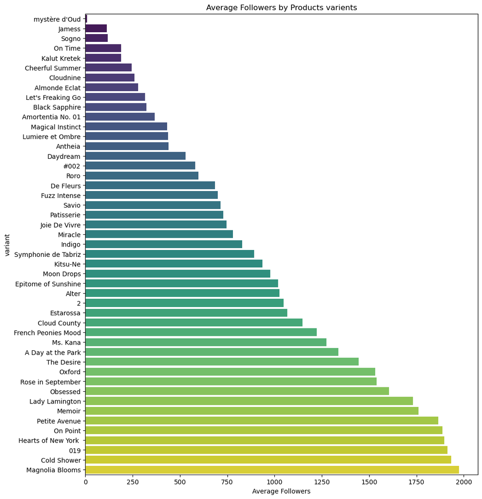

```python
pt.figure(figsize=(11,13))
pt.title('Average Followers by Products varients')
pt.xlabel('Average Followers')
pt.ylabel('Product Varients')
sb.barplot(x=avg_followers_variant.values,y=avg_followers_variant.index,palette='viridis');
```

**Business Problem statement 3:- Visualising The distribution of the perfumes sizes using Pie Diagram.

```python
sizes=df['size'].value_counts()
sizes
```

```
size
50     65
30     21
100    13
35     10
55      3
105     2
85      1
75      1
45      1
33      1
10      1
40      1
Name: count, dtype: int64
```

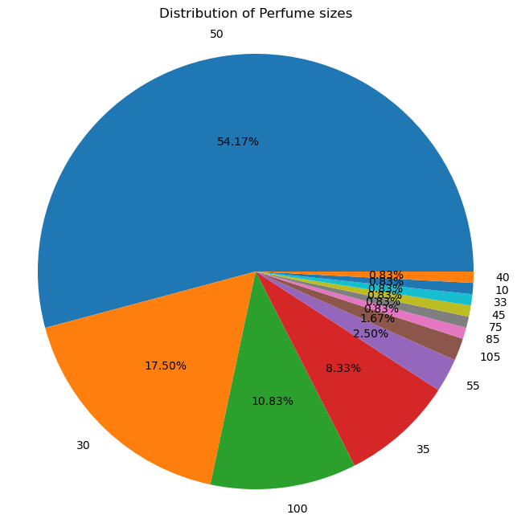

```python
pt.figure(figsize=(8,8))
pt.pie(sizes,labels=sizes.index,autopct='%1.2f%%',radius=1.1)
pt.title("Distribution of Perfume sizes")
pt.show()
```

*observations:: The size 50 has highest market share i.e 54.17% of the total , the second highest is size 30 with 17.50% of share followed by size 100 with 10.83% share, it can be seen that the sizes 40,10,33,45,75,85 has similar shares i.e 0.83% each.

**Business Problem statement 4:- Investigate the distribution of prices based on the concentration of the product.

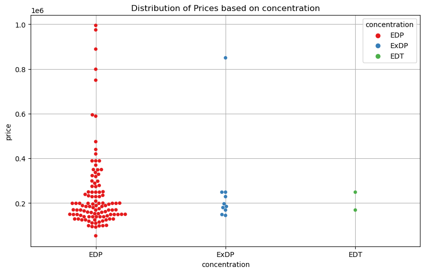

```python
pt.figure(figsize=(10,6))
pt.title("Distribution of Prices based on concentration")
sb.swarmplot(x='concentration',y='price',hue='concentration',data=df,palette='Set1')
pt.grid(True)
pt.show()
```

**Business Problem statement 5:- Performance of the client company over the Years comparing prices year-wise.

```python
prices_brand=df.groupby('year')[['price']].sum()
prices_brand
```

| year | price |
| --- | --- |
| 2013 | 235000.0 |
| 2015 | 125000.0 |
| 2018 | 1190200.0 |
| 2019 | 1973000.0 |
| 2020 | 5143550.0 |
| 2021 | 4460999.0 |
| 2022 | 8905150.0 |
| 2023 | 6725600.0 |
| 2024 | 149900.0 |

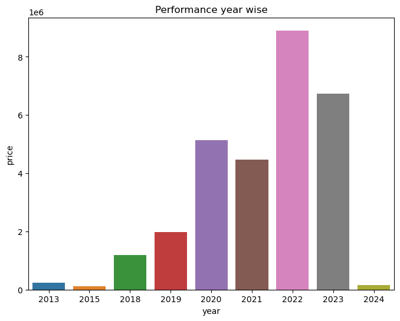

```python
pt.figure(figsize=(8,6))
pt.xlabel('Year')
pt.ylabel('Annual Price')
pt.title('Performance year wise')
sb.barplot(x=prices_brand.index,y=prices_brand['price'])
pt.show()
```

```python
prices_brand_mean=df.groupby('year')[['price']].mean()
```

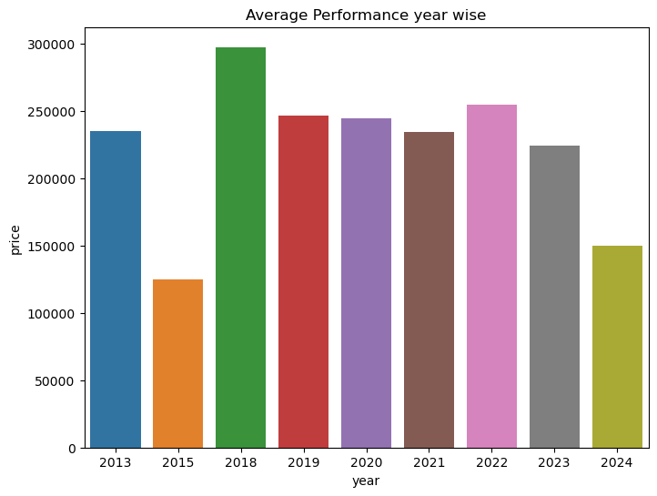

```python
pt.figure(figsize=(8,6))
pt.xlabel('Year')
pt.ylabel('Annual Price')
pt.title('Average Performance year wise')
sb.barplot(x=prices_brand_mean.index,y=prices_brand_mean['price'])
pt.show()
```

**Business Problem statement 6:- Trend of the Instagram followers over the Year, this will help to understand the overall Socialmedia Engagament of the Perfume Company.

```python
followers_trend=df.groupby('year')['followers'].sum().reset_index()
followers_trend
```

|  | year | followers |
| --- | --- | --- |
| 0 | 2013 | 11200 |
| 1 | 2015 | 35100 |
| 2 | 2018 | 659100 |
| 3 | 2019 | 946322 |
| 4 | 2020 | 574249 |
| 5 | 2021 | 305308 |
| 6 | 2022 | 446352 |
| 7 | 2023 | 70069 |
| 8 | 2024 | 94400 |

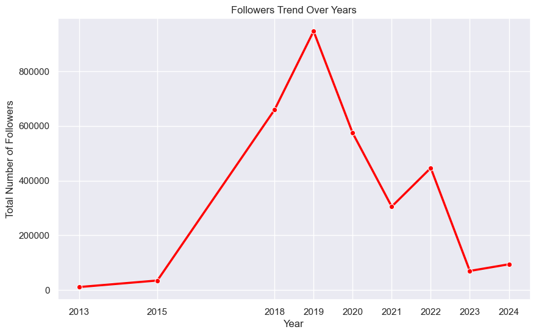

```python
pt.figure(figsize=(10,6))
pt.title('Followers Trend Over Years')
ax=sb.lineplot(data=followers_trend,x='year',y='followers',linewidth=2.5,marker='o',color='red')
pt.xlabel('Year')
pt.ylabel('Total Number of Followers')
ax.set(xticks=followers_trend['year'])
pt.show()
```

*observation: it Can be seen that the Social Media engagement of the Perfume company increased gradually from the begining and peaked in the year 2019, however there is a considerable decrease in the followers numbers after 2019 it might be because of Covid-19,clients really needs to work on social media Subject Area as number of releases increased over the period as seen below.

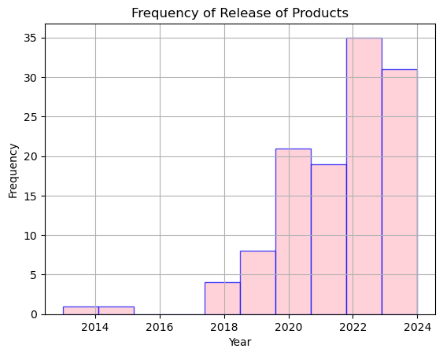

```python
pt.title('Frequency of Release of Products')
df['year'].plot(kind='hist',color='pink',edgecolor='blue',alpha=0.7,xlabel='Year')
pt.grid(True)
```

**Business Problem statement 7:- Analysing the empty Mid_notes1 and Base_notes1 and thier relationship with the Followers and Pricing with respect to the Variant.

```python
df.columns
```

```
Index(['brand', 'instagram_link', 'followers', 'year', 'variant',
       'variant_link', 'concentration', 'size', 'price', 'price_per_ml',
       'top_notes1', 'top_notes2', 'top_notes3', 'top_notes4', 'top_notes5',
       'top_notes6', 'mid_notes1', 'mid_notes2', 'mid_notes3', 'mid_notes4',
       'mid_notes5', 'mid_notes6', 'mid_notes7', 'base_notes1', 'base_notes2',
       'base_notes3', 'base_notes4', 'base_notes5', 'base_notes6',
       'base_notes7'],
      dtype='object')
```

**Note:: earlier Default has been introduced to handle empty values.

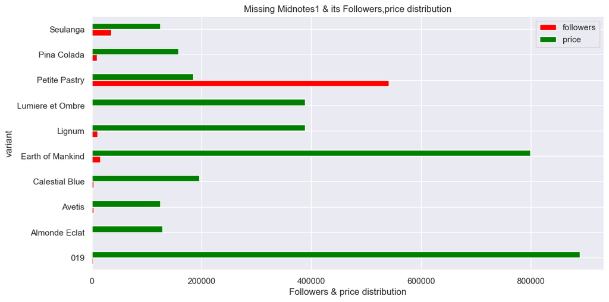

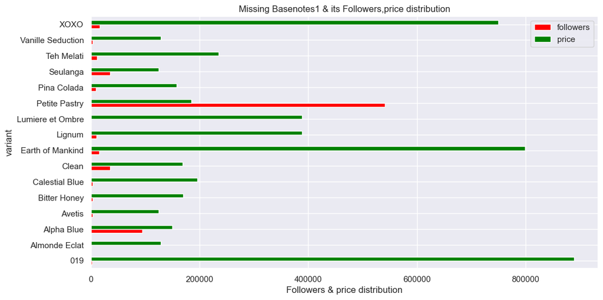

```python
m=df.query('mid_notes1.str.contains("Default")').groupby('variant')[['followers','price']].sum()\
.plot(kind='barh',figsize=(12,6),color=["red","green"]\
,title='Missing Midnotes1 & its Followers,price distribution')
m.set_xlabel('Followers & price distribution')
n=df.query('base_notes1.str.contains("Default")').groupby('variant')[['followers','price']].sum()\
.plot(kind='barh',figsize=(12,6),color=["red","green"]
,title='Missing Basenotes1 & its Followers,price distribution')
n.set_xlabel('Followers & price distribution')
pt.show()
```

*observations: There are some variants which are aggresively priced without the proper information about the product variant in the midnote1 and basenote1 as shown in the above figure, By providing the sufficient details the number of followers may increase here.

```python
df.head()
```

|  | brand | instagram_link | followers | year | variant | variant_link | concentration | size | price | price_per_ml | ... | mid_notes5 | mid_notes6 | mid_notes7 | base_notes1 | base_notes2 | base_notes3 | base_notes4 | base_notes5 | base_notes6 | base_notes7 |
| --- | --- | --- | --- | --- | --- | --- | --- | --- | --- | --- | --- | --- | --- | --- | --- | --- | --- | --- | --- | --- | --- |
| 0 | Alchemist | https://www.instagram.com/alchemist.fragrance/ | 17800 | 2022 | Powder Room | https://shopee.co.id/alchemist.fragrance/17137... | EDP | 50 | 199000.0 | 3980.00 | ... | Default_mid5 | Default_mid6 | Default_mid7 | Musk | Marine | Sandalwood | Default_base4 | Default_base5 | Default_base6 | Default_base7 |
| 1 | Alien Objects | https://www.instagram.com/alienobjects/ | 15700 | 2019 | XOXO | https://shopee.co.id/alienobjects/14283008217 | EDP | 50 | 750000.0 | 15000.00 | ... | Default_mid5 | Default_mid6 | Default_mid7 | Default_base1 | Default_base2 | Default_base3 | Default_base4 | Default_base5 | Default_base6 | Default_base7 |
| 2 | ALT Perfumery | https://www.instagram.com/alt.perfumery/ | 6528 | 2021 | Moroccan Sunset | https://shopee.co.id/altperfumery/12639590547 | EDP | 50 | 229000.0 | 4580.00 | ... | Default_mid5 | Default_mid6 | Default_mid7 | Vanilla | Caramel | Musk | Cedarwood | Default_base5 | Default_base6 | Default_base7 |
| 3 | Ara Scent | https://www.instagram.com/ara.scent/ | 119 | 2023 | Sogno | https://shopee.co.id/ara.scent/22247002537 | EDP | 30 | 139000.0 | 4633.33 | ... | Default_mid5 | Default_mid6 | Default_mid7 | Amber | Vanilla | Default_base3 | Default_base4 | Default_base5 | Default_base6 | Default_base7 |
| 4 | Aromes | https://www.instagram.com/aromes.id/ | 15700 | 2022 | Crazy Sexy | https://shopee.co.id/aromes.id/19521086160 | EDP | 50 | 299000.0 | 5980.00 | ... | Default_mid5 | Default_mid6 | Default_mid7 | Vanilla | Patchouli | Cashmeran | Musk | Default_base5 | Default_base6 | Default_base7 |

5 rows × 30 columns

**Business Problem statement 8:- Brand variant-wise price to followers Analysis to understand the possibilities to optimize the pricing according to the existing customers.

```python
improvement=df.groupby(['variant'])[['followers','price']].mean().\
sort_values('followers',ascending=True)\
.query('followers<=3000')
improvement=improvement.reset_index()
```

```python
#a) Immediate Action Required
improvement.query('followers<=500')
```

|  | variant | followers | price |
| --- | --- | --- | --- |
| 0 | mystère d'Oud | 9.0 | 148800.0 |
| 1 | Jamess | 114.0 | 100500.0 |
| 2 | Sogno | 119.0 | 139000.0 |
| 3 | On Time | 188.0 | 149000.0 |
| 4 | Kalut Kretek | 188.0 | 350000.0 |
| 5 | Cheerful Summer | 245.0 | 98000.0 |
| 6 | Cloudnine | 259.0 | 125000.0 |
| 7 | Almonde Eclat | 279.0 | 129000.0 |
| 8 | Let's Freaking Go | 316.0 | 229000.0 |
| 9 | Black Sapphire | 324.0 | 120000.0 |
| 10 | Amortentia No. 01 | 366.0 | 189000.0 |
| 11 | Magical Instinct | 432.0 | 250000.0 |
| 12 | Lumiere et Ombre | 437.0 | 389000.0 |
| 13 | Antheia | 440.0 | 132000.0 |

```python
#a) Strick Action Required
improvement.query('followers>500').reset_index(drop=True)
```

|  | variant | followers | price |
| --- | --- | --- | --- |
| 0 | Daydream | 530.0 | 249000.0 |
| 1 | #002 | 581.0 | 289000.0 |
| 2 | Roro | 598.0 | 249000.0 |
| 3 | De Fleurs | 685.0 | 185000.0 |
| 4 | Fuzz Intense | 700.0 | 149000.0 |
| 5 | Savio | 715.0 | 153000.0 |
| 6 | Patisserie | 728.0 | 995000.0 |
| 7 | Joie De Vivre | 745.0 | 199000.0 |
| 8 | Miracle | 781.0 | 229250.0 |
| 9 | Indigo | 830.0 | 239000.0 |
| 10 | Symphonie de Tabriz | 891.0 | 975000.0 |
| 11 | Kitsu-Ne | 936.0 | 139000.0 |
| 12 | Moon Drops | 978.0 | 92900.0 |
| 13 | Epitome of Sunshine | 1019.0 | 249000.0 |
| 14 | Alter | 1027.0 | 139000.0 |
| 15 | 2 | 1048.0 | 195000.0 |
| 16 | Estarossa | 1067.0 | 129000.0 |
| 17 | Cloud County | 1148.0 | 115000.0 |
| 18 | French Peonies Mood | 1223.0 | 179900.0 |
| 19 | Ms. Kana | 1275.0 | 139000.0 |
| 20 | A Day at the Park | 1338.0 | 349000.0 |
| 21 | The Desire | 1444.0 | 175000.0 |
| 22 | Oxford | 1533.0 | 199000.0 |
| 23 | Rose in September | 1540.0 | 199000.0 |
| 24 | Obsessed | 1605.0 | 319000.0 |
| 25 | Lady Lamington | 1731.0 | 159900.0 |
| 26 | Memoir | 1761.0 | 165000.0 |
| 27 | Petite Avenue | 1866.0 | 169000.0 |
| 28 | On Point | 1888.0 | 249000.0 |
| 29 | Hearts of New York | 1896.0 | 159000.0 |
| 30 | 019 | 1913.0 | 889000.0 |
| 31 | Cold Shower | 1932.0 | 329000.0 |
| 32 | Magnolia Blooms | 1975.0 | 162000.0 |
| 33 | Walking The Aisle | 2115.0 | 169000.0 |
| 34 | Johan Malik | 2197.0 | 170000.0 |
| 35 | Pablo | 2213.0 | 149000.0 |
| 36 | Summer Garden | 2255.0 | 139300.0 |
| 37 | Party Anthem | 2586.0 | 150000.0 |
| 38 | Calestial Blue | 2980.0 | 196000.0 |

*observations: The above 39 variants also need market price reforms and Discounts,additionally there is a immediate need to improve the social-media campaigning of the above 39 Variants.